# Biostat 203B Homework 1

Due Feb 10 @ 11:59PM

Zian ZHUANG

```r
os <- sessionInfo()$running
if (str_detect(os, "Linux")) {
  mimic_path <- "/usr/203b-data/mimic-iv"
} else if (str_detect(os, "Windows")) {
  mimic_path <- "."
}
```

Use tidyverse (ggpot2, dplyr) to explore the [MIMIC-IV](https://mimic-iv.mit.edu) data introduced in [homework 1](https://ucla-biostat203b-2021winter.github.io/hw/hw1/hw1.html).

```r
system(str_c("tree -s -L 2 ", shQuote(mimic_path)), intern = TRUE)
```

```
##  [1] "/usr/203b-data/mimic-iv"
##  [2] "├── [         78]  core"
##  [3] "│   ├── [   17224843]  admissions.csv.gz"
##  [4] "│   ├── [    2884996]  patients.csv.gz"
##  [5] "│   └── [   51188147]  transfers.csv.gz"
##  [6] "├── [       4096]  hosp"
##  [7] "│   ├── [     430049]  d_hcpcs.csv.gz"
##  [8] "│   ├── [   26575586]  diagnoses_icd.csv.gz"
##  [9] "│   ├── [     723633]  d_icd_diagnoses.csv.gz"
## [10] "│   ├── [     564422]  d_icd_procedures.csv.gz"
## [11] "│   ├── [      14845]  d_labitems.csv.gz"
## [12] "│   ├── [   12913088]  drgcodes.csv.gz"
## [13] "│   ├── [  518077567]  emar.csv.gz"
## [14] "│   ├── [  479709397]  emar_detail.csv.gz"
## [15] "│   ├── [    1415469]  hcpcsevents.csv.gz"
```

[output cut: 20 more lines]

## Q1. PhysioNet credential

### Q1.1

At this moment, you should already get credentialed on the PhysioNet. Please include a screenshot of your `Data Use Agreement for the MIMIC-IV (v0.4)`.

> **solution**:

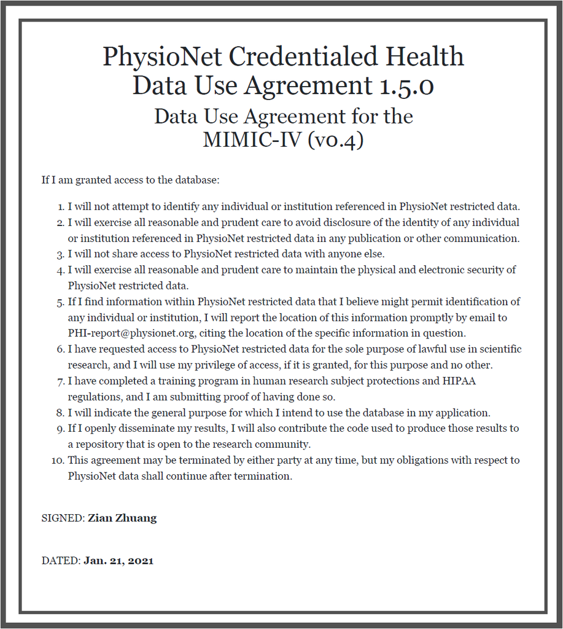

## Q2. `read.csv` (base R) vs `read_csv` (tidyverse) vs `fread` (data.table)

There are quite a few utilities in R for reading data files. Let us test the speed of reading a moderate sized compressed csv file, `admissions.csv.gz`, by three programs: `read.csv` in base R, `read_csv` in tidyverse, and `fread` in the popular data.table package. Is there any speed difference?

In this homework, we stick to the tidyverse.

> **solution**:

```r
.timer <- function(fun_input){
  timestart <- Sys.time()
  adm <- fun_input(str_c(mimic_path, "/core/admissions.csv.gz"))
  timeend <- Sys.time()
  return(timeend - timestart)
}
lapply(list("read_csv" = read_csv,
            "read.csv" = read.csv,
            "fread" = fread), .timer)
```

[output not shown]

## Q3. ICU stays

`icustays.csv.gz` (https://mimic-iv.mit.edu/docs/datasets/icu/icustays/) contains data about Intensive Care Units (ICU) stays. Summarize following variables using appropriate numerics or graphs:

```r
icustays <- read_csv(str_c(mimic_path, "/icu/icustays.csv.gz"))
```

### Q3.1 how many unique `stay_id`?

> **solution**:

```r
icustays %>%
  distinct(stay_id) %>%
  nrow() %>%
  str_c(., " unique stay_id")
```

```
## [1] "69619 unique stay_id"
```

### Q3.2 how many unique `subject_id`?

> **solution**:

```r
icustays %>%
  distinct(subject_id) %>%
  nrow() %>%
  str_c(., " unique subject_id")
```

```
## [1] "50048 unique subject_id"
```

### Q3.3 length of ICU stay

> **solution**: **please note that we took the log scale of x-axis to present data in a more readable way**

```r
icustays$los %>% summary
```

```
##     Min.  1st Qu.   Median     Mean  3rd Qu.     Max.
##   0.0347   1.1339   2.0611   3.9805   4.2022 599.2497
```

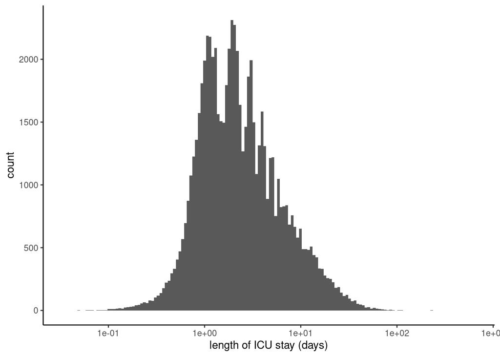

```r
ggplot(data = icustays) +
  geom_histogram(mapping = aes(x = los), bins = 150) +
  scale_x_log10() +
  xlab("length of ICU stay (days)")+
  theme_classic()
```

### Q3.4 first ICU unit

> **solution**:

```r
icustays %>%
  group_by(first_careunit) %>%
  summarise(n = n()) %>%
  arrange(desc(n))
```

```
## # A tibble: 11 x 2
##    first_careunit                                       n
##    <chr>                                            <int>
##  1 Medical Intensive Care Unit (MICU)               15587
##  2 Medical/Surgical Intensive Care Unit (MICU/SICU) 12206
##  3 Cardiac Vascular Intensive Care Unit (CVICU)     10920
##  4 Surgical Intensive Care Unit (SICU)              10915
##  5 Trauma SICU (TSICU)                               8268
##  6 Coronary Care Unit (CCU)                          7985
##  7 Neuro Surgical Intensive Care Unit (Neuro SICU)   1558
##  8 Neuro Intermediate                                1240
##  9 Neuro Stepdown                                     861
## 10 PACU                                                68
## 11 Medicine                                            11
```

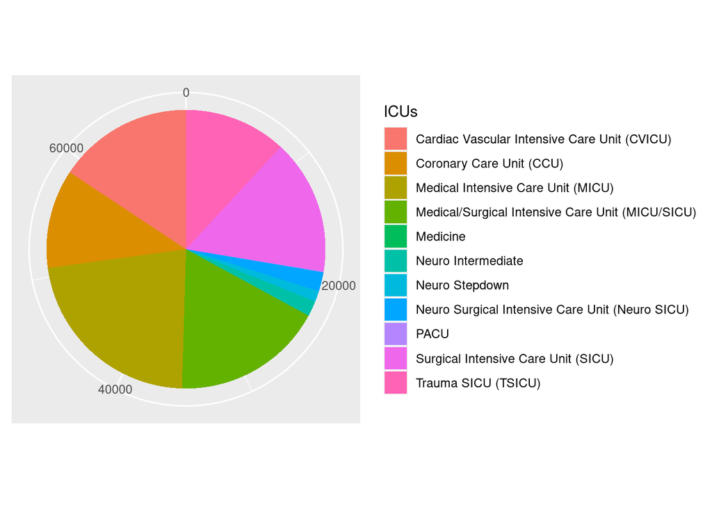

```r
ggplot(data = icustays,
       mapping = aes(x = factor(1), fill = first_careunit)) +
  scale_fill_discrete(name = "ICUs") +
  xlab(NULL) +
  ylab(NULL) +
  geom_bar() +
  coord_polar("y") +
  theme(axis.ticks = element_blank(),
        axis.text.y = element_blank())
```

### Q3.5 last ICU unit

> **solution**:

```r
icustays %>%
  group_by(last_careunit) %>%
  summarise(n = n()) %>%
  arrange(desc(n))
```

```
## # A tibble: 9 x 2
##   last_careunit                                        n
##   <chr>                                            <int>
## 1 Medical Intensive Care Unit (MICU)               16221
## 2 Medical/Surgical Intensive Care Unit (MICU/SICU) 12069
## 3 Cardiac Vascular Intensive Care Unit (CVICU)     10946
## 4 Surgical Intensive Care Unit (SICU)              10874
## 5 Trauma SICU (TSICU)                               7881
## 6 Coronary Care Unit (CCU)                          7859
## 7 Neuro Intermediate                                1663
## 8 Neuro Stepdown                                    1200
## 9 Neuro Surgical Intensive Care Unit (Neuro SICU)    906
```

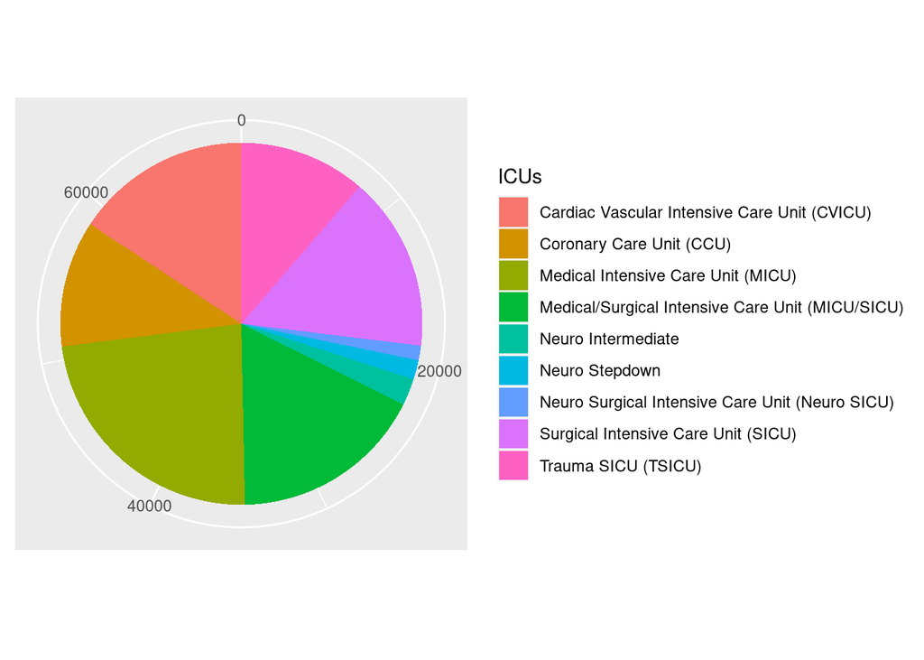

```r
ggplot(data = icustays,
       mapping = aes(x = factor(1), fill = last_careunit)) +
  scale_fill_discrete(name = "ICUs") +
  xlab(NULL) +
  ylab(NULL) +
  geom_bar() +
  coord_polar("y") +
  theme(axis.ticks = element_blank(),
        axis.text.y = element_blank())
```

## Q4. `admission` data

Information of the patients admitted into hospital is available in `admissions.csv.gz`. See https://mimic-iv.mit.edu/docs/datasets/core/admissions/ for details of each field in this file. Summarize following variables using appropriate graphs. Explain any patterns you observe.

```r
adm <- read_csv(str_c(mimic_path, "/core/admissions.csv.gz"))
```

Note it is possible that one patient (uniquely identified by the `subject_id`) is admitted into hospital multiple times. When summarizing some demographic information, it makes sense to summarize based on unique patients.

### Q4.1 admission year

> **solution**:

```r
adm %<>% mutate(admission_year=year(adm$admittime))
adm$admission_year %>% summary
```

```
##    Min. 1st Qu.  Median    Mean 3rd Qu.    Max.
##    2105    2134    2154    2154    2174    2212
```

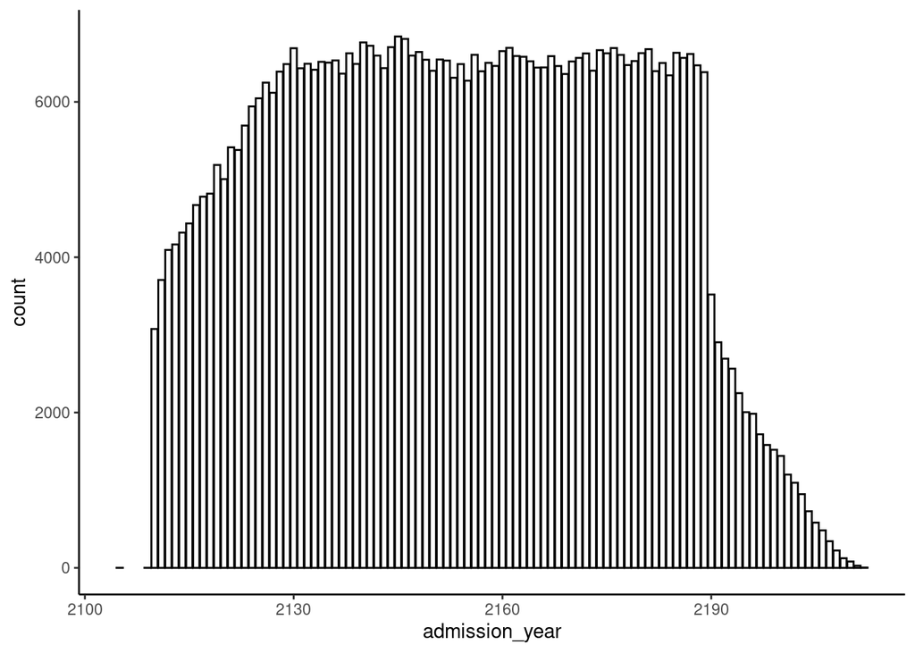

```r
ggplot(adm, aes(x = admission_year)) +
  geom_bar(colour = "black", fill = "white") +
  theme_classic()
```

### Q4.2 admission month

> **solution**:

```r
adm %<>% mutate(admission_month=month(adm$admittime))
adm %>%
  group_by(admission_month) %>%
  summarise(n = n(), .groups = "keep") %>%
  arrange(desc(n))
```

```
## # A tibble: 12 x 2
## # Groups:   admission_month [12]
##    admission_month     n
##              <dbl> <int>
##  1               8 44603
##  2               5 44597
##  3               7 44473
##  4              10 44440
##  5              12 44418
##  6               1 44342
##  7               3 44197
##  8               4 43409
##  9               9 43352
## 10               6 43207
## 11              11 43088
## 12               2 40394
```

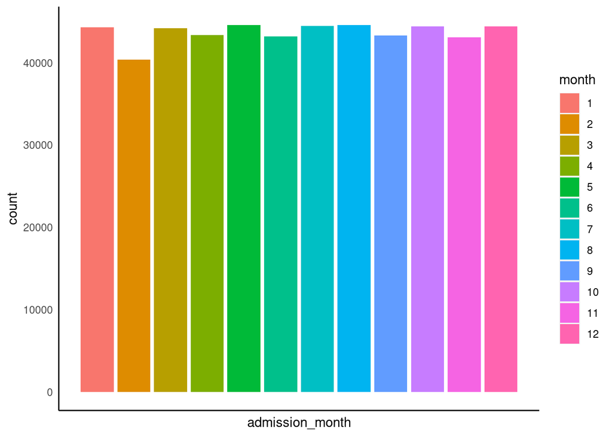

```r
ggplot(adm) +
  geom_bar(mapping = aes(x = admission_month,
                         fill = admission_month %>% as.factor)) +
  scale_fill_discrete(name = "month") +
  theme(axis.text.x = element_blank(),
        axis.ticks = element_blank(),
        panel.background = element_blank(),
        axis.line = element_line(colour = "black"))
```

### Q4.3 admission month day

> **solution**:

```r
adm %<>% mutate(admission_monthday=day(adm$admittime))
adm$admission_monthday %>% summary
```

```
##    Min. 1st Qu.  Median    Mean 3rd Qu.    Max.
##    1.00    8.00   16.00   15.73   23.00   31.00
```

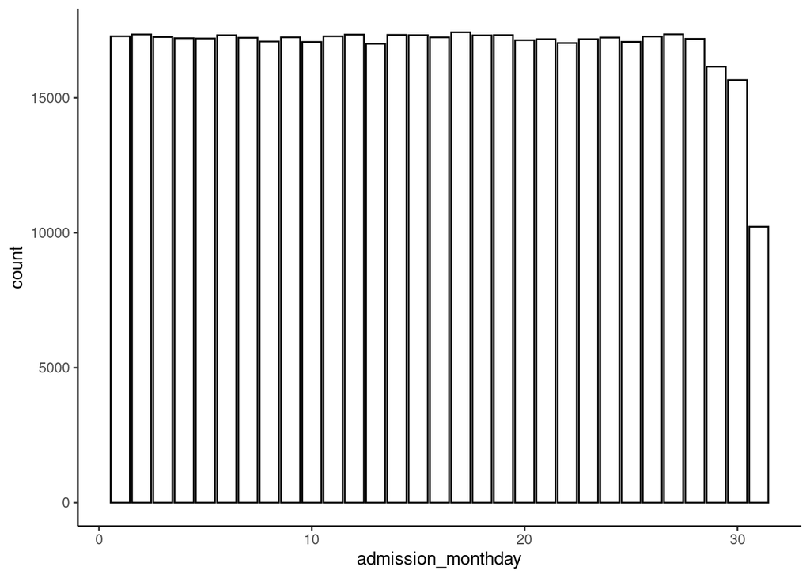

```r
ggplot(adm, aes(x = admission_monthday)) +
  geom_bar(colour = "black", fill = "white") +
  theme_classic()
```

### Q4.4 admission week day

> **solution**:

```r
adm %<>% mutate(admission_weekday=wday(adm$admittime))
adm %>%
  group_by(admission_weekday) %>%
  summarise(n = n(), .groups = "keep") %>%
  arrange(desc(n))
```

```
## # A tibble: 7 x 2
## # Groups:   admission_weekday [7]
##   admission_weekday     n
##               <dbl> <int>
## 1                 7 75587
## 2                 1 75015
## 3                 2 74879
## 4                 6 74832
## 5                 4 74763
## 6                 5 74741
## 7                 3 74703
```

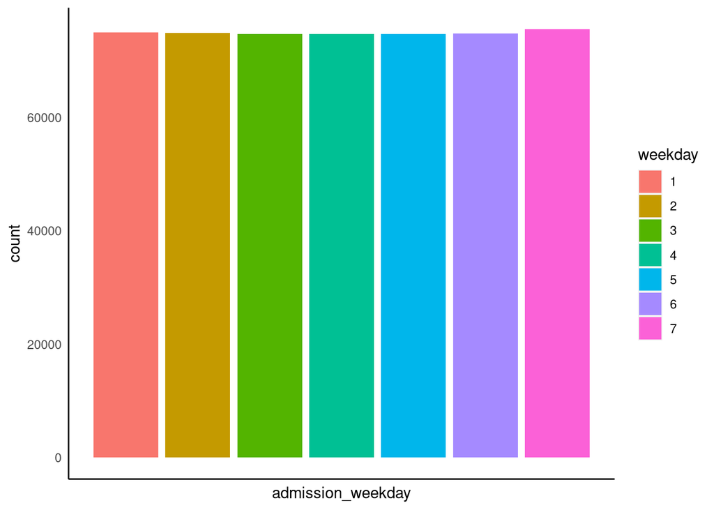

```r
ggplot(adm) +
  geom_bar(mapping = aes(x = admission_weekday,
                         fill = admission_weekday %>% as.factor)) +
  scale_fill_discrete(name = "weekday") +
  theme(axis.text.x = element_blank(),
        axis.ticks = element_blank(),
        panel.background = element_blank(),
        axis.line = element_line(colour = "black"))
```

### Q4.5 admission hour (anything unusual?)

> **solution**:

```r
adm %<>% mutate(admission_hour=hour(adm$admittime))
adm$admission_hour %>% summary
```

```
##    Min. 1st Qu.  Median    Mean 3rd Qu.    Max.
##    0.00    7.00   14.00   12.86   19.00   23.00
```

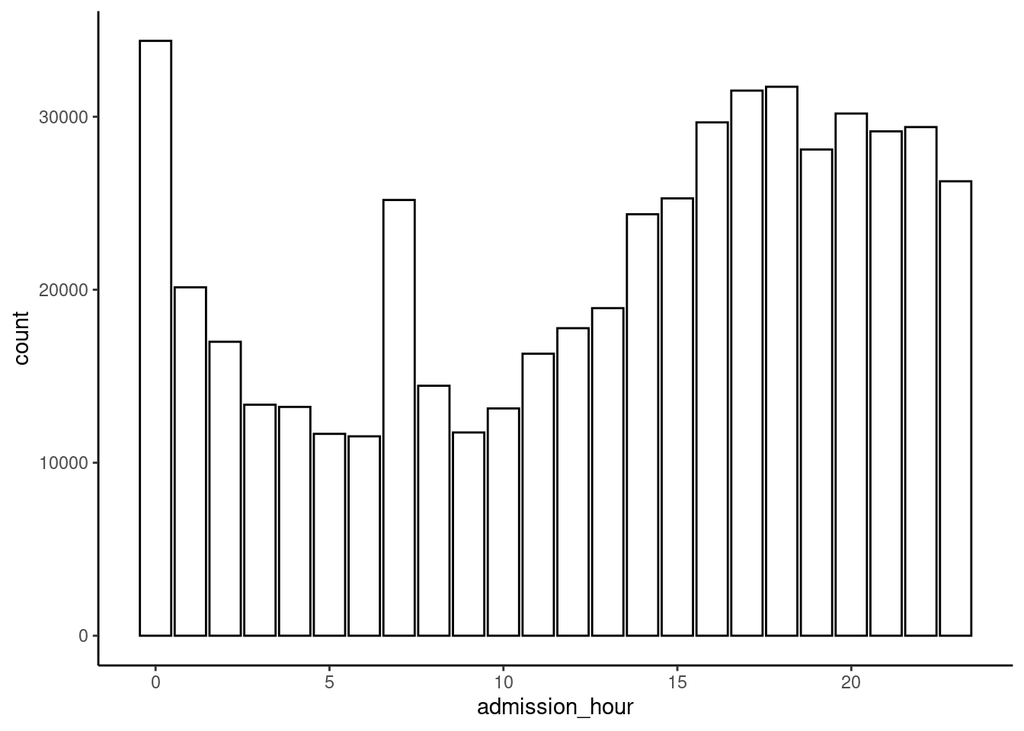

```r
ggplot(adm, aes(x = admission_hour)) +
  geom_bar(colour = "black", fill = "white") +
  theme_classic()
```

### Q4.6 number of deaths in each year

Firstly we need check whether the indicators for the death cases are consistent (`deathtime`,`hospital_expire_flag`).

```r
adm %>%
  mutate(test = ifelse((is.na(deathtime) == FALSE &
                          hospital_expire_flag == 0)|
                         (is.na(deathtime) == TRUE &
                            hospital_expire_flag == 1), 1, 0)) %>%
  filter(test == 1) %>%
  select(subject_id, deathtime,
         hospital_expire_flag, discharge_location)
```

```
## # A tibble: 13 x 4
##    subject_id deathtime           hospital_expire_flag discharge_location
##         <dbl> <dttm>                             <dbl> <chr>
##  1   13594875 NA                                     1 <NA>
##  2   14126394 NA                                     1 DIED
##  3   11600106 NA                                     1 DIED
##  4   18463717 NA                                     1 DIED
##  5   10676055 NA                                     1 <NA>
##  6   10676055 NA                                     1 DIED
##  7   13556244 NA                                     1 DIED
##  8   11181752 NA                                     1 DIED
##  9   11553956 NA                                     1 DIED
## 10   12588483 NA                                     1 DIED
## 11   12811067 NA                                     1 DIED
## 12   10176453 NA                                     1 DIED
## 13   18751817 NA                                     1 DIED
```

**Note**: We found that there are some cases whose `deathtime` is missing but `hospital_expire_flag` equals 1. Referring to the other terms (e.g. `discharge_location`), `hospital_expire_flag` is turn out to be the more presise indicator. Thus, we decided to choose **`hospital_expire_flag`** as the indicator for death cases.

> **solution**:

```r
adm %>%
  filter(hospital_expire_flag == 1) %>%
  group_by(admission_year) %>%
  summarise(n = n(), .groups = "keep") %>%
  arrange(desc(n))
```

```
## # A tibble: 102 x 2
## # Groups:   admission_year [102]
##    admission_year     n
##             <dbl> <int>
##  1           2185   140
##  2           2138   136
##  3           2131   135
##  4           2134   134
##  5           2164   132
##  6           2133   129
##  7           2179   129
##  8           2130   128
##  9           2135   128
## 10           2175   127
## # … with 92 more rows
```

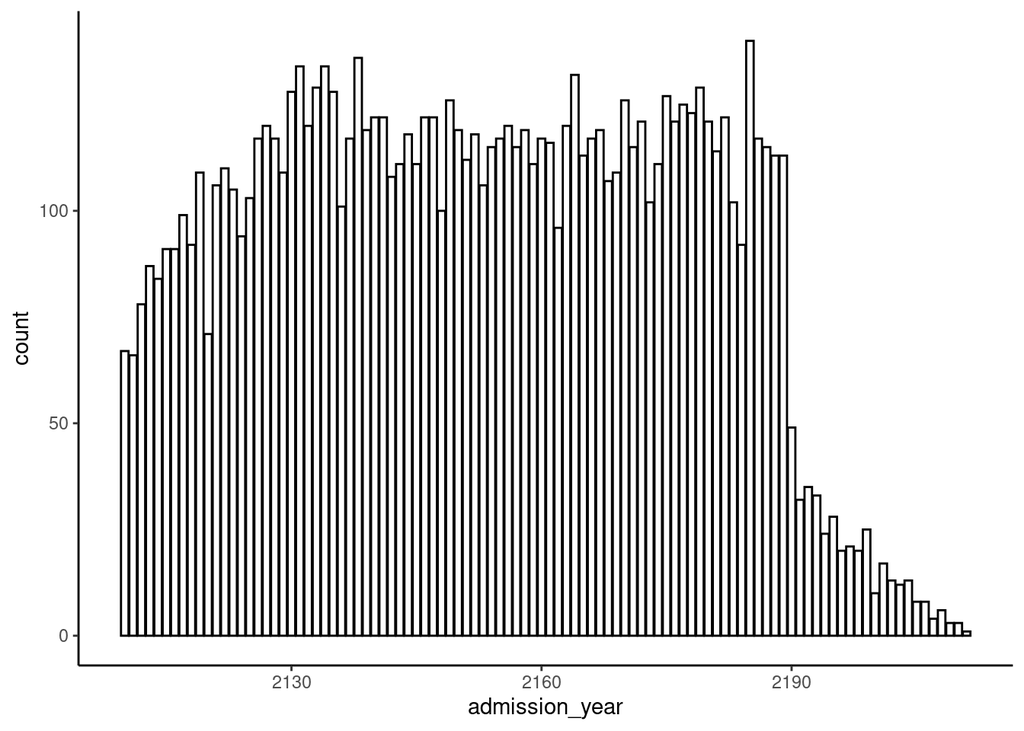

```r
ggplot(adm %>% filter(is.na(deathtime) == FALSE),
       aes(x = admission_year)) +
  geom_bar(colour = "black", fill = "white") +
  theme_classic()
```

### Q4.7 admission type

> **solution**:

```r
adm %>%
  group_by(admission_type) %>%
  summarise(n = n(), .groups = "keep") %>%
  arrange(desc(n))
```

```
## # A tibble: 9 x 2
## # Groups:   admission_type [9]
##   admission_type                   n
##   <chr>                        <int>
## 1 EW EMER.                    158032
## 2 EU OBSERVATION              100938
## 3 ELECTIVE                     72077
## 4 OBSERVATION ADMIT            55532
## 5 URGENT                       47970
## 6 SURGICAL SAME DAY ADMISSION  41103
## 7 DIRECT EMER.                 21595
## 8 DIRECT OBSERVATION           20014
## 9 AMBULATORY OBSERVATION        7259
```

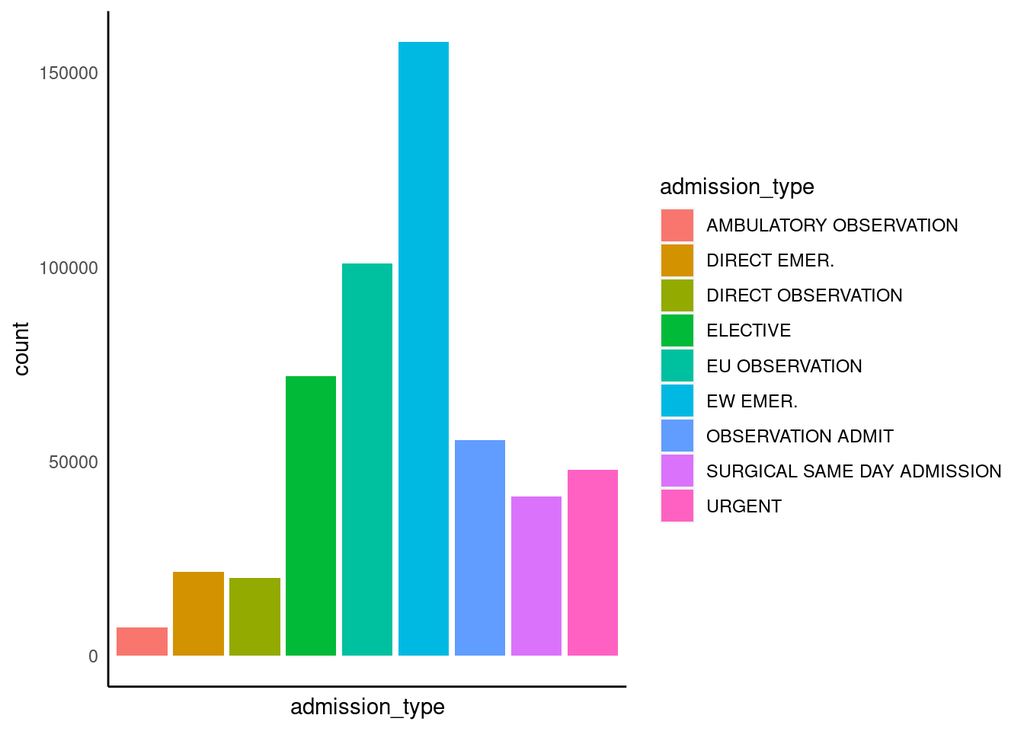

```r
ggplot(adm) +
  geom_bar(mapping = aes(x = admission_type, fill = admission_type)) +
  theme(axis.text.x = element_blank(),
        axis.ticks = element_blank(),
        panel.background = element_blank(),
        axis.line = element_line(colour = "black"))
```

### Q4.8 number of admissions per patient

> **solution**:

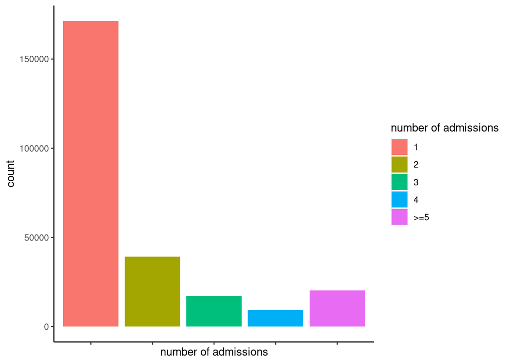

```r
number_of_ad <- adm %>%
  group_by(subject_id) %>%
  summarise(n = n(), .groups = "keep") %>%
  arrange(n) %>%
  mutate(num = ifelse(n>=5, 5, n))
number_of_ad$num %<>% ordered(levels = c("1", "2", "3", "4", "5"))
ggplot(number_of_ad) +
  geom_bar(mapping = aes(x = num , fill = num)) +
  xlab("number of admissions") +
  scale_fill_discrete(name = "number of admissions",
                      labels = c("1", "2", "3", "4", ">=5")) +
  theme(panel.background = element_blank(),
        axis.text.x = element_blank(),
        axis.line = element_line(colour = "black"))
```

### Q4.9 admission location

> **solution**:

```r
adm %>%
  group_by(admission_location) %>%
  summarise(n = n(), .groups = "keep") %>%
  arrange(desc(n))
```

```
## # A tibble: 12 x 2
## # Groups:   admission_location [12]
##    admission_location                          n
##    <chr>                                   <int>
##  1 EMERGENCY ROOM                         246241
##  2 PHYSICIAN REFERRAL                     127648
##  3 <NA>                                    60437
##  4 TRANSFER FROM HOSPITAL                  39150
##  5 WALK-IN/SELF REFERRAL                   16715
##  6 CLINIC REFERRAL                         10678
##  7 PROCEDURE SITE                           8453
##  8 PACU                                     6075
##  9 INTERNAL TRANSFER TO OR FROM PSYCH       4484
## 10 TRANSFER FROM SKILLED NURSING FACILITY   4069
## 11 INFORMATION NOT AVAILABLE                 379
## 12 AMBULATORY SURGERY TRANSFER               191
```

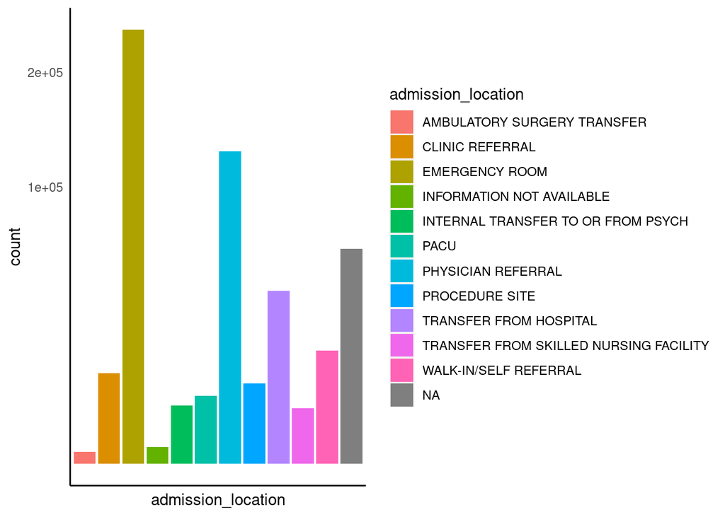

```r
ggplot(adm) +
  geom_bar(mapping = aes(x = admission_location, fill = admission_location)) +
  scale_y_sqrt() +
  theme(axis.text.x = element_blank(),
        axis.ticks = element_blank(),
        panel.background = element_blank(),
        axis.line = element_line(colour = "black"))
```

### Q4.9 discharge location

> **solution**:

```r
adm %>%
  group_by(discharge_location) %>%
  summarise(n = n(), .groups = "keep") %>%
  arrange(desc(n))
```

```
## # A tibble: 14 x 2
## # Groups:   discharge_location [14]
##    discharge_location                n
##    <chr>                         <int>
##  1 HOME                         222298
##  2 <NA>                         127183
##  3 HOME HEALTH CARE              86077
##  4 SKILLED NURSING FACILITY      46223
##  5 REHAB                         11354
##  6 DIED                           9257
##  7 CHRONIC/LONG TERM ACUTE CARE   7596
##  8 HOSPICE                        3680
##  9 ACUTE HOSPITAL                 3500
## 10 AGAINST ADVICE                 2719
## 11 PSYCH FACILITY                 2421
## 12 OTHER FACILITY                 1459
## 13 ASSISTED LIVING                 585
## 14 HEALTHCARE FACILITY             168
```

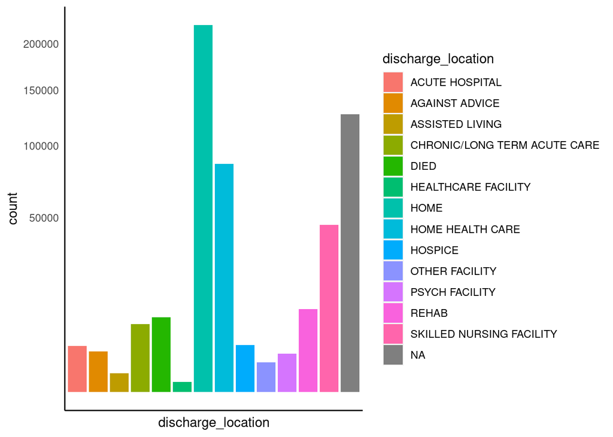

```r
ggplot(adm) +
  geom_bar(mapping = aes(x = discharge_location, fill = discharge_location)) +
  scale_y_sqrt() +
  theme(axis.text.x = element_blank(),
        axis.ticks = element_blank(),
        panel.background = element_blank(),
        axis.line = element_line(colour = "black"))
```

### Q4.10 insurance

> **solution**: (summarized based on unique patients)

```r
adm %>%
  distinct(subject_id, .keep_all = TRUE) %>%
  group_by(insurance) %>%
  summarise(n = n(), .groups = "keep") %>%
  arrange(desc(n))
```

```
## # A tibble: 3 x 2
## # Groups:   insurance [3]
##   insurance      n
##   <chr>      <int>
## 1 Other     174336
## 2 Medicare   60221
## 3 Medicaid   22809
```

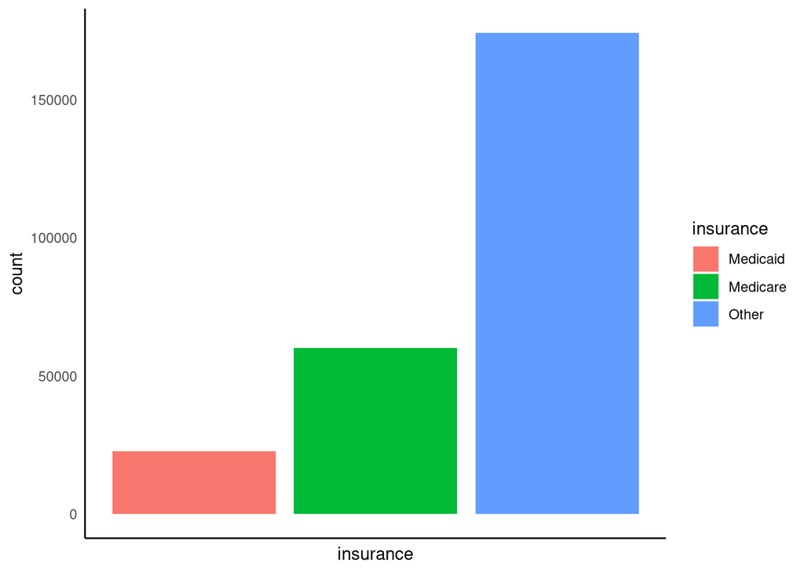

```r
ggplot(adm %>%
  distinct(subject_id, .keep_all = TRUE)) +
  geom_bar(mapping = aes(x = insurance, fill = insurance)) +
  theme(axis.text.x = element_blank(),
        axis.ticks = element_blank(),
        panel.background = element_blank(),
        axis.line = element_line(colour = "black"))
```

### Q4.11 language

> **solution**: (summarized based on unique patients)

```r
adm %>%
  distinct(subject_id, .keep_all = TRUE) %>%
  group_by(language) %>%
  summarise(n = n(), .groups = "keep") %>%
  arrange(desc(n))
```

```
## # A tibble: 2 x 2
## # Groups:   language [2]
##   language      n
##   <chr>     <int>
## 1 ENGLISH  238387
## 2 ?         18979
```

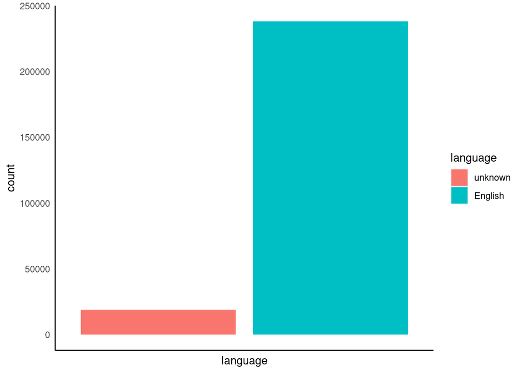

```r
ggplot(adm %>%
  distinct(subject_id, .keep_all = TRUE)) +
  geom_bar(mapping = aes(x = language, fill = language)) +
  scale_fill_discrete(label = c("unknown","English")) +
  theme(axis.text.x = element_blank(),
        axis.ticks = element_blank(),
        panel.background = element_blank(),
        axis.line = element_line(colour = "black"))
```

### Q4.12 marital status

> **solution**: (summarized based on unique patients)

```r
adm %>%
  distinct(subject_id, .keep_all = TRUE) %>%
  group_by(marital_status) %>%
  summarise(n = n(), .groups = "keep") %>%
  arrange(desc(n))
```

```
## # A tibble: 5 x 2
## # Groups:   marital_status [5]
##   marital_status     n
##   <chr>          <int>
## 1 MARRIED        84946
## 2 SINGLE         78458
## 3 <NA>           63866
## 4 WIDOWED        17837
## 5 DIVORCED       12259
```

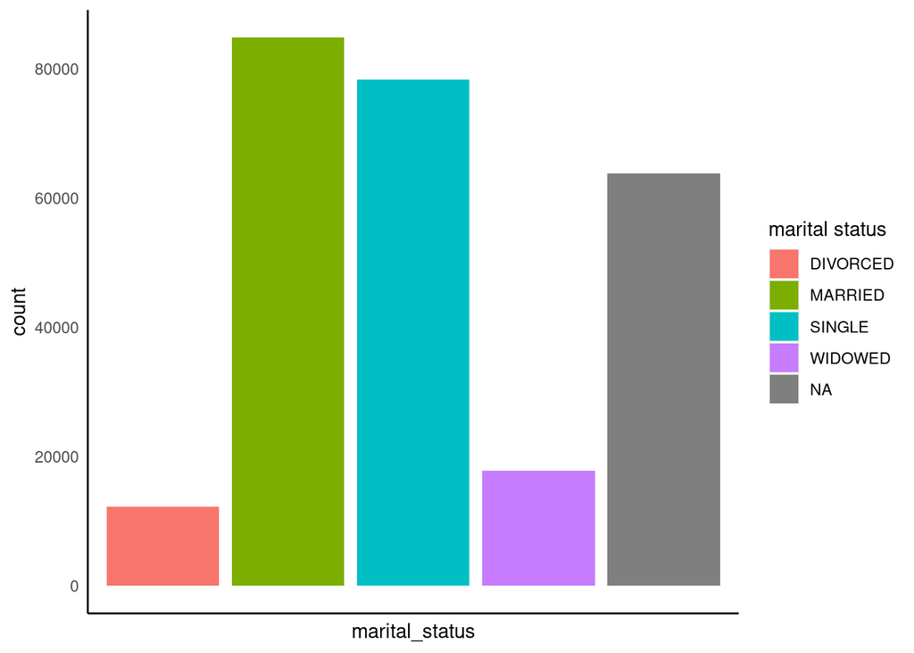

```r
ggplot(adm %>%
  distinct(subject_id, .keep_all = TRUE)) +
  geom_bar(mapping = aes(x = marital_status, fill = marital_status)) +
  scale_fill_discrete(name = "marital status") +
  theme(axis.text.x = element_blank(),
        axis.ticks = element_blank(),
        panel.background = element_blank(),
        axis.line = element_line(colour = "black"))
```

### Q4.13 ethnicity

> **solution**: (summarized based on unique patients)

```r
adm %>%
  distinct(subject_id, .keep_all = TRUE) %>%
  group_by(ethnicity) %>%
  summarise(n = n(), .groups = "keep") %>%
  arrange(desc(n))
```

```
## # A tibble: 8 x 2
## # Groups:   ethnicity [8]
##   ethnicity                          n
##   <chr>                          <int>
## 1 WHITE                         159642
## 2 BLACK/AFRICAN AMERICAN         31253
## 3 UNKNOWN                        16593
## 4 ASIAN                          16544
## 5 OTHER                          15888
## 6 HISPANIC/LATINO                13364
## 7 UNABLE TO OBTAIN                3131
## 8 AMERICAN INDIAN/ALASKA NATIVE    951
```

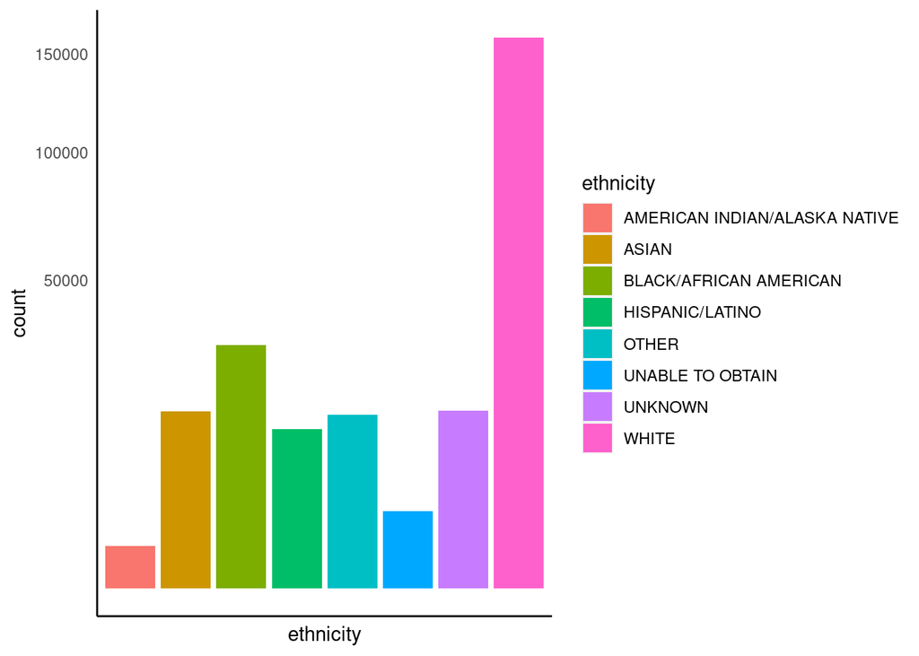

```r
ggplot(adm %>%
  distinct(subject_id, .keep_all = TRUE)) +
  geom_bar(mapping = aes(x = ethnicity, fill = ethnicity)) +
  scale_fill_discrete(name = "ethnicity") +
  scale_y_sqrt() +
  theme(axis.text.x = element_blank(),
        axis.ticks = element_blank(),
        panel.background = element_blank(),
        axis.line = element_line(colour = "black"))
```

### Q4.14 death

> **solution**:

```r
adm %<>% mutate(death = ifelse(hospital_expire_flag == 1, "Yes", "No"))
adm %>%
  group_by(death) %>%
  summarise(n = n(), .groups = "keep") %>%
  arrange(desc(n))
```

```
## # A tibble: 2 x 2
## # Groups:   death [2]
##   death      n
##   <chr>  <int>
## 1 No    515151
## 2 Yes     9369
```

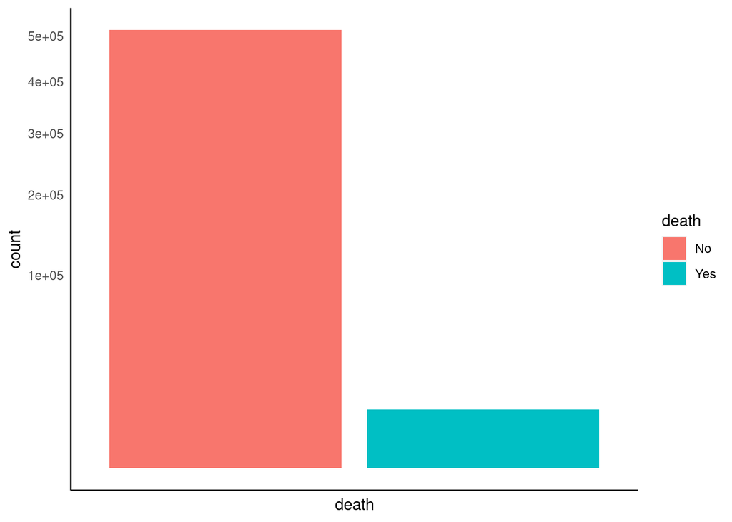

```r
ggplot(adm) +
  geom_bar(mapping = aes(x = death, fill = death)) +
  scale_fill_discrete(name = "death") +
  scale_y_sqrt() +
  theme(axis.text.x = element_blank(),
        axis.ticks = element_blank(),
        panel.background = element_blank(),
        axis.line = element_line(colour = "black"))
```

## Q5. `patient` data

Explore `patients.csv.gz` (https://mimic-iv.mit.edu/docs/datasets/core/patients/) and summarize following variables using appropriate numerics and graphs:

```r
patients <- read_csv(str_c(mimic_path, "/core/patients.csv.gz"))
```

### Q5.1 `gender`

> **solution**: (summarized based on unique patients)

```r
patients %>%
  distinct(subject_id, .keep_all = TRUE) %>%
  group_by(gender) %>%
  summarise(n = n(), .groups = "keep")
```

```
## # A tibble: 2 x 2
## # Groups:   gender [2]
##   gender      n
##   <chr>   <int>
## 1 F      200226
## 2 M      182994
```

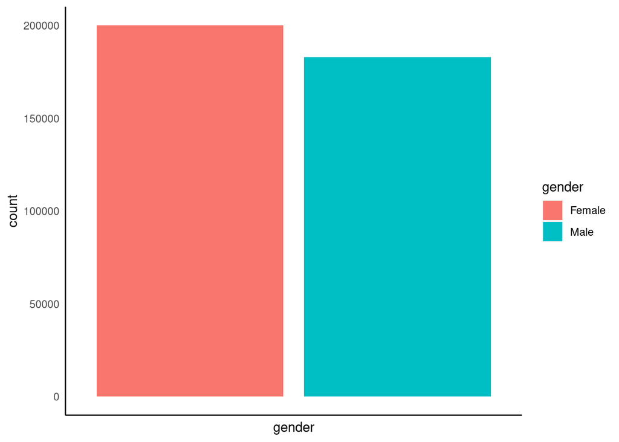

```r
ggplot(patients %>%
  distinct(subject_id, .keep_all = TRUE)) +
  geom_bar(mapping = aes(x = gender, fill = gender)) +
  scale_fill_discrete(name = "gender",
                      label = c("Female", "Male")) +
  theme(axis.text.x = element_blank(),
        axis.ticks = element_blank(),
        panel.background = element_blank(),
        axis.line = element_line(colour = "black"))
```

### Q5.2 `anchor_age`

(explain pattern you see)

> **solution**: (summarized based on unique patients)

```r
patients %>%
  distinct(subject_id, .keep_all = TRUE) %>%
  select(anchor_age) %>%
  summary
```

```
##    anchor_age
##  Min.   : 0.00
##  1st Qu.:22.00
##  Median :41.00
##  Mean   :40.95
##  3rd Qu.:62.00
##  Max.   :91.00
```

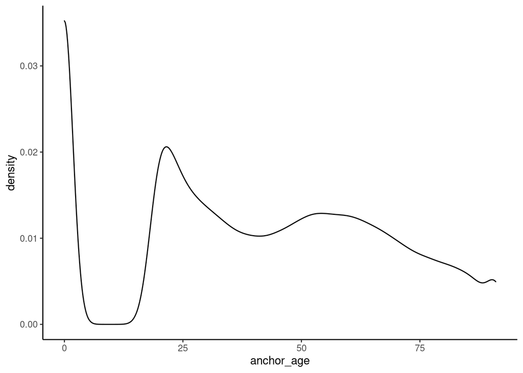

```r
ggplot(patients %>%
  distinct(subject_id, .keep_all = TRUE)) +
  geom_density(mapping = aes(x = anchor_age)) +
  xlab("anchor_age")+
  theme_classic()
```

According to the summary statistics, the mean anchor age of patients are 41. And figure presents that the anchor age of patients has two peak at 0 and 25 respectively. Very few patients have anchor age at around 10. Then we presumed that the peak in age 0 should be correspond to the missing data or some corrupted data. Thus, we filter out the anchor_age which equals 0 and plot again.

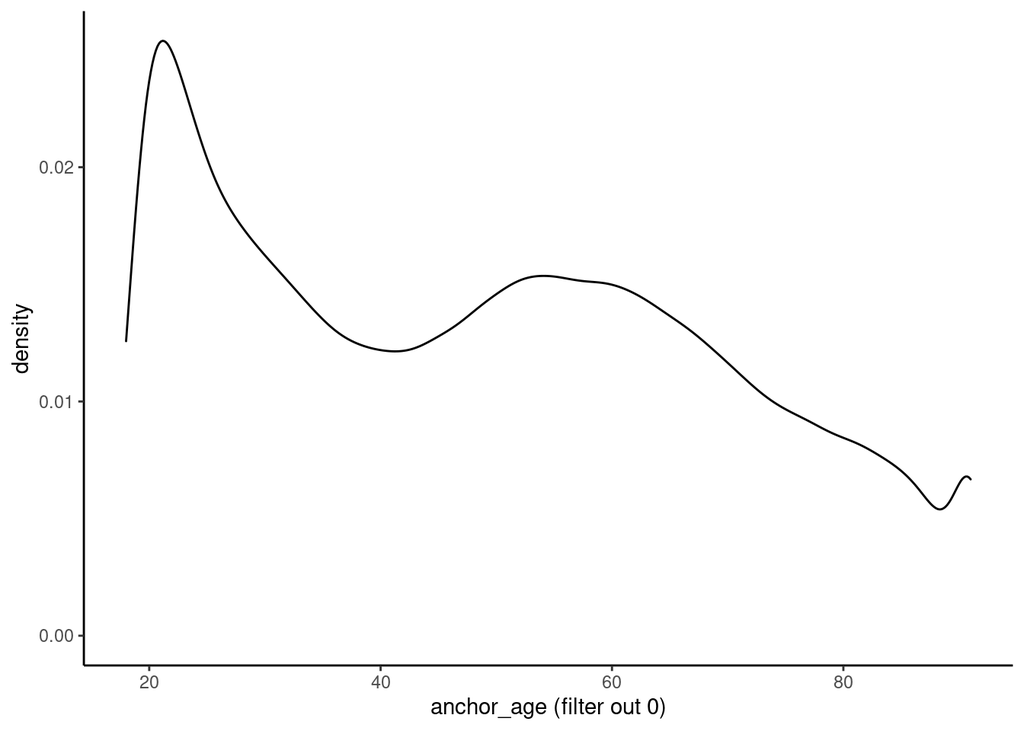

```r
patients %>%
  distinct(subject_id, .keep_all = TRUE) %>%
  filter(anchor_age != 0) %>%
  ggplot() +
  geom_density(mapping = aes(x = anchor_age)) +
  xlab("anchor_age (filter out 0)")+
  theme_classic()
```

## Q6. Lab results

`labevents.csv.gz` (https://mimic-iv.mit.edu/docs/datasets/hosp/labevents/) contains all laboratory measurements for patients.

We are interested in the lab measurements of creatinine (50912), potassium (50971), sodium (50983), chloride (50902), bicarbonate (50882), hematocrit (51221), white blood cell count (51301), glucose (50931), magnesium (50960), calcium (50893), and lactate (50813). Find the `itemid`s of these lab measurements from `d_labitems.csv.gz` and retrieve a subset of `labevents.csv.gz` only containing these items.

**solution**:

**Quick check the data file**

```r
readLines(str_c(mimic_path, "/hosp/labevents.csv.gz"), n = 5L)
```

```
## [1] "labevent_id,subject_id,hadm_id,specimen_id,itemid,charttime,storetime,value,valuenum,valueuom,ref_range_lower,ref_range_upper,flag,priority,comments"
## [2] "30331194,12455438,24471620,6107018,51277,2151-05-06 04:45:00,2151-05-06 06:24:00,13.9,13.9,%,10.5,15.5,,STAT,"
## [3] "30331195,12455438,24471620,6107018,51279,2151-05-06 04:45:00,2151-05-06 06:24:00,3.55,3.55,m/uL,3.9,5.2,abnormal,STAT,"
## [4] "30331196,12455438,24471620,6107018,51301,2151-05-06 04:45:00,2151-05-06 06:24:00,16.3,16.3,K/uL,4,10,abnormal,STAT,"
## [5] "30331197,12455438,24471620,6107018,52167,2151-05-06 04:45:00,2151-05-06 06:24:00,46.7,46.7,fL,35.1,46.3,abnormal,STAT,"
```

**Begin data processing**

```r
item_list <- c("creatinine", "potassium", "sodium",
               "chloride", "bicarbonate", "hematocrit",
               "white blood cell", "glucose",
               "magnesium", "calcium", "lactate")
lab_name <- c("subject_id", "hadm_id", "itemid",
              "charttime", "valuenum")
#
#read and save
#
if (!file.exists("labevents_icu.csv.gz")){
  system.time(labevents <- fread(str_c(mimic_path, "/hosp/labevents.csv.gz"),
                     select = lab_name, nThread = getDTthreads()))
  labevents %>%
    semi_join(icustays, by = c("subject_id", "hadm_id")) %>%
    fwrite("labevents_icu.csv.gz", nThread = getDTthreads())
}
labitems <- fread(str_c(mimic_path, "/hosp/d_labitems.csv.gz"))
system.time(labevents_icu <- fread("labevents_icu.csv.gz",
                                   nThread = getDTthreads()))
#
#define lookup function
#
.look_up <- function(x, type = "look_up", input = NULL){
  if(type == "look_up"){
    lookup <- input %>%
      filter(str_detect(label, regex(x, ignore_case = TRUE))) %>%
      select(itemid, label)
    return(lookup)
  } else if(type == "find_id"){
    count <- input %>%
      filter(itemid %in% as_vector(x$itemid)) %>%
      count(itemid) %>%
      arrange(desc(n)) %>% .[1, 1]
    return(count)
  }
}
#
#find data matching item id and save
#
idkey_all <- lapply(item_list %>% as.list,
                    .look_up,
                    input = labitems)
idkey <- sapply(idkey_all,
                .look_up,
                type="find_id",
                input = labevents_icu)
if (!file.exists("labevents_icu_selected.csv.gz")){
  labevents_icu %>%
  filter(itemid %in% as_vector(idkey)) %>%
  left_join(Reduce(rbind, idkey_all), by = "itemid") %>%
  fwrite("labevents_icu_selected.csv.gz", nThread = getDTthreads())
}
```

**Check the content of the processed data**

```r
labevents_icu <- fread("labevents_icu_selected.csv.gz",
                         nThread = getDTthreads())
labevents_icu
```

```
##          subject_id  hadm_id itemid           charttime valuenum          label
##       1:   12457441 21673651  50882 2135-08-16 23:45:00     28.0    Bicarbonate
##       2:   12457441 21673651  50893 2135-08-16 23:45:00      7.5 Calcium, Total
##       3:   12457441 21673651  50902 2135-08-16 23:45:00     95.0       Chloride
##       4:   12457441 21673651  50912 2135-08-16 23:45:00      0.6     Creatinine
##       5:   12457441 21673651  50960 2135-08-16 23:45:00      1.5      Magnesium
##      ---
## 8021348:   12452675 20652838  50902 2163-06-06 07:05:00    102.0       Chloride
## 8021349:   12452675 20652838  50912 2163-06-06 07:05:00      0.7     Creatinine
## 8021350:   12452675 20652838  50960 2163-06-06 07:05:00      1.9      Magnesium
## 8021351:   12452675 20652838  50971 2163-06-06 07:05:00      3.3      Potassium
## 8021352:   12452675 20652838  50983 2163-06-06 07:05:00    137.0         Sodium
```

## Q7. Vitals from chartered events

We are interested in the vitals for ICU patients: heart rate, mean and systolic blood pressure (invasive and noninvasive measurements combined), body temperature, SpO2, and respiratory rate. Find the `itemid`s of these vitals from `d_items.csv.gz` and retrieve a subset of `chartevents.csv.gz` only containing these items.

`chartevents.csv.gz` (https://mimic-iv.mit.edu/docs/datasets/icu/chartevents/) contains all the charted data available for a patient. During their ICU stay, the primary repository of a patient’s information is their electronic chart. The `itemid` variable indicates a single measurement type in the database. The `value` variable is the value measured for `itemid`.

`d_items.csv.gz` (https://mimic-iv.mit.edu/docs/datasets/icu/d_items/) is the dictionary for the `itemid` in `chartevents.csv.gz`.

**solution**:

**Quick check the data file**

```r
readLines(str_c(mimic_path, "/icu/chartevents.csv.gz"), n = 5L)
```

```
## [1] "subject_id,hadm_id,stay_id,charttime,storetime,itemid,value,valuenum,valueuom,warning"
## [2] "19999068,21606769,31096823,2161-08-30 20:00:00,2161-08-30 19:51:00,223990,Normal,,,0"
## [3] "19999068,21606769,31096823,2161-08-30 20:00:00,2161-08-30 19:51:00,223991,Weak,,,0"
## [4] "19999068,21606769,31096823,2161-08-30 20:00:00,2161-08-30 19:52:00,223999,Teeth/Tissue WNL,,,0"
## [5] "19999068,21606769,31096823,2161-08-30 20:00:00,2161-08-30 19:52:00,224000,Patent,,,0"
```

**Begin data processing**

```r
item_list2 <- c("heart rate", "arterial blood pressure systolic",
                "arterial blood pressure mean",
                "invasive blood pressure mean",
                "invasive blood pressure systolic", "temperature",
                "SpO2", "respiratory rate")
char_name <- c("subject_id", "hadm_id", "itemid",
              "charttime", "valuenum")
#
#read and save
#
if (!file.exists("chartevents_icu.csv.gz")){
  system.time(chartevents <- fread(str_c(mimic_path,
                                         "/icu/chartevents.csv.gz"),
                     select = char_name, nThread = getDTthreads()))
  chartevents %>%
    semi_join(icustays, by = c("subject_id", "hadm_id")) %>%
    fwrite("chartevents_icu.csv.gz", nThread = getDTthreads())
}
d_items <- fread(str_c(mimic_path, "/icu/d_items.csv.gz"))
system.time(chartevents_icu <- fread("chartevents_icu.csv.gz",
                                     nThread = getDTthreads()))
#
#find data matching item id and save
#
idkey_all2 <- lapply(item_list2 %>% as.list,
                     .look_up,
                     input = d_items)
idkey2 <- sapply(idkey_all2,
                 .look_up,
                 type="find_id",
                 input = chartevents_icu)
if (!file.exists("chartevents_icu_selected.csv.gz")){
  chartevents_icu %>%
  filter(itemid %in% as_vector(idkey2)) %>%
  left_join(Reduce(rbind, idkey_all2), by = "itemid") %>%
  fwrite("chartevents_icu_selected.csv.gz", nThread = getDTthreads())
}
```

**Check the content of the processed data**

```r
chartevents_icu <- fread("chartevents_icu_selected.csv.gz",
                         nThread = getDTthreads())
chartevents_icu
```

```
##           subject_id  hadm_id itemid           charttime valuenum
##        1:   19999068 21606769 224642 2161-08-30 20:00:00       NA
##        2:   10003700 28623837 220179 2165-04-24 05:28:00      152
##        3:   10003700 28623837 220181 2165-04-24 05:28:00      110
##        4:   10003700 28623837 220045 2165-04-24 05:30:00       65
##        5:   10003700 28623837 220210 2165-04-24 05:30:00       14
##       ---
## 31003457:   19999068 21606769 224642 2161-08-29 23:00:00       NA
## 31003458:   19999068 21606769 224642 2161-08-30 03:00:00       NA
## 31003459:   19999068 21606769 224642 2161-08-30 08:00:00       NA
## 31003460:   19999068 21606769 224642 2161-08-30 12:00:00       NA
## 31003461:   19999068 21606769 224642 2161-08-30 16:00:00       NA
##                                          label
##        1:                     Temperature Site
##        2: Non Invasive Blood Pressure systolic
##        3:     Non Invasive Blood Pressure mean
##        4:                           Heart Rate
##        5:                     Respiratory Rate
##       ---
## 31003457:                     Temperature Site
## 31003458:                     Temperature Site
## 31003459:                     Temperature Site
## 31003460:                     Temperature Site
## 31003461:                     Temperature Site
```

## Q8. Putting things together

Let us create a tibble for all ICU stays, where rows are

- first ICU stay of each unique patient
- adults (age at admission > 18)

and columns contain at least following variables

- all variables in `icustays.csv.gz`
- all variables in `admission.csv.gz`
- all variables in `patients.csv.gz`
- first lab measurements during ICU stay
- first vitals measurement during ICU stay
- an indicator variable whether the patient died within 30 days of hospital admission

**solution**:

```r
which(duplicated(labevents_icu) == TRUE) %>% length
```

```
## [1] 691
```

```r
which(duplicated(chartevents_icu) == TRUE) %>% length
```

```
## [1] 0
```

After a quick check, we found that there are some patients have more than one record at a single time point (duplicated resords). Thus, we need to only keep one record.

```r
#keep the first lab\vitals measurements
labevents_icu %>%
  mutate_at(vars(charttime), ymd_hms) %>%
  left_join(icustays %>%
              select(c("subject_id", "hadm_id", "intime")),
            by = c("subject_id", "hadm_id")) %>%
  filter(charttime >= intime) %>%
  group_by(subject_id, label) %>%
  arrange(charttime, .by_group = FALSE) %>%
  slice_head(n = 1) %>%
  select(-c(charttime, itemid, intime)) %>%
  spread(key = label, value = valuenum) %>%
  fwrite("labevents_icu_final.csv.gz", nThread = getDTthreads())

chartevents_icu %>%
  mutate_at(vars(charttime), ymd_hms) %>%
  left_join(icustays %>%
              select(c("subject_id", "hadm_id", "intime")),
            by = c("subject_id", "hadm_id")) %>%
  filter(charttime >= intime) %>%
  group_by(subject_id, label) %>%
  arrange(charttime, .by_group = FALSE) %>%
  slice_head(n = 1) %>%
  select(-c(charttime, itemid, intime)) %>%
  spread(key = label, value = valuenum) %>%
  fwrite("chartevents_icu_final.csv.gz", nThread = getDTthreads())
```

Then we can prepare the final dataset

```r
#read in data
labevents_icu <- fread("labevents_icu_final.csv.gz",
                         nThread = getDTthreads())
chartevents_icu <- fread("chartevents_icu_final.csv.gz",
                         nThread = getDTthreads())
#all variables in `icustays.csv.gz`
final_icu_dataset <- icustays %>%
  # first ICU stay of each unique patient
  group_by(subject_id) %>%
  slice_min(intime) %>%
  # add all variables in `admission.csv.gz`
  left_join(adm, by = c("subject_id", "hadm_id")) %>%
  # add all variables in `patients.csv.gz`
  left_join(patients, by = "subject_id") %>%
  mutate(age_at_adm = year(admittime) - anchor_year + anchor_age) %>%
  # adults (age at admission > 18)
  filter(age_at_adm >= 18) %>%
  # add first vitals measurement during ICU stay
  left_join(chartevents_icu, by = c("subject_id", "hadm_id")) %>%
  # add first lab measurements during ICU stay
  left_join(labevents_icu, by = c("subject_id", "hadm_id")) %>%
  # filter out all death cases [indicator: "hospital_expire_flag"]
  mutate(death_binary = ifelse(hospital_expire_flag == 1, "Yes", "No")) %>%
  # indicator variable whether the patient died within 30 days of admission
  mutate(death_30 = ifelse(deathtime - intime <= 30, "Yes", "No"))

print(final_icu_dataset, width = Inf)
```

```
## # A tibble: 50,048 x 54
## # Groups:   subject_id [50,048]
##    subject_id  hadm_id  stay_id first_careunit
##         <dbl>    <dbl>    <dbl> <chr>
##  1   10000032 29079034 37529680 Medical Intensive Care Unit (MICU)
##  2   10000980 26913865 36742749 Medical Intensive Care Unit (MICU)
##  3   10001217 24597018 30327812 Surgical Intensive Care Unit (SICU)
##  4   10001725 25563031 37542711 Medical/Surgical Intensive Care Unit (MICU/SICU)
##  5   10001884 26184834 31832304 Medical Intensive Care Unit (MICU)
##  6   10002013 23581541 37106138 Cardiac Vascular Intensive Care Unit (CVICU)
##  7   10002155 23822395 34599502 Coronary Care Unit (CCU)
##  8   10002223 22494570 39908879 Trauma SICU (TSICU)
##  9   10002428 28662225 31956612 Medical Intensive Care Unit (MICU)
## 10   10002443 21329021 35217462 Coronary Care Unit (CCU)
##    last_careunit                                    intime
```

[output cut: 156 more lines]

Set NA as “No” in indicator variable and compare with with `death_binary`

```r
final_icu_dataset %>%
  ungroup() %>%
  mutate_at(vars(death_30),
            function(x){ifelse(is.na(x) == TRUE, "No", x)}) %>%
  count(death_30, death_binary)
```

```
## # A tibble: 3 x 3
##   death_30 death_binary     n
##   <chr>    <chr>        <int>
## 1 No       No           44865
## 2 No       Yes            217
## 3 Yes      Yes           4966
```